# Notebook 09: Summarize Project

Author

Shirshak Aryal

Published

July 4, 2026

## 1. Project Pipeline Overview

The project follows a **linear preprocessing pipeline (Notebooks 00–04)** that **branches into two independent analytical streams after EDA**, before **converging into the final integration notebook (Notebook 08)**:

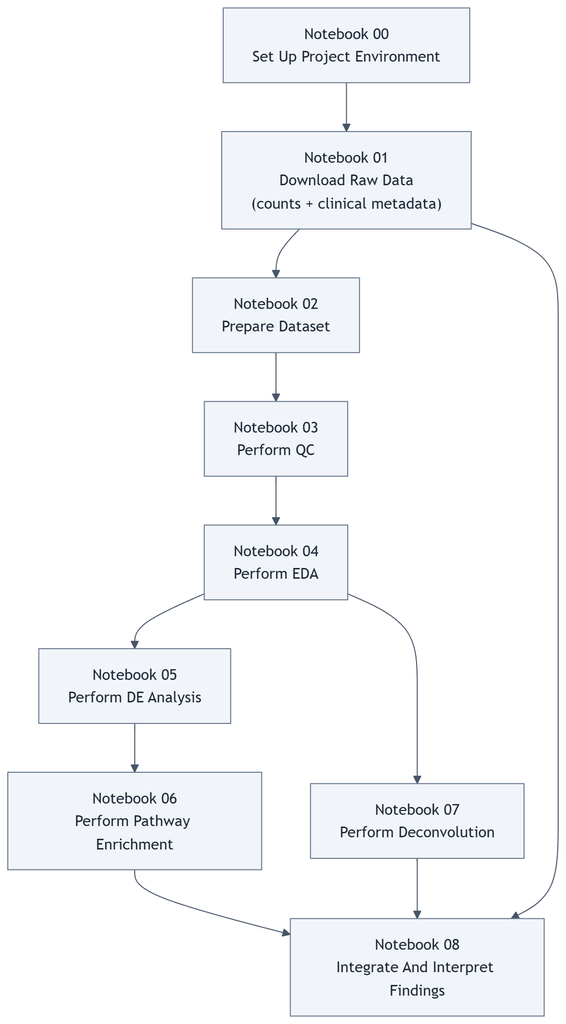

Project Pipeline Overview

## 2. Project Notebooks

### 2.0. Notebook 00: Set Up Project Environment

- **Established the project directory structure**
- **Installed and verified all required R packages**
- **Confirmed the computational environment**

This notebook is a **one-time setup** step with **no analytical outputs or figures**.

### 2.1. Notebook 01: Download Raw Data

**Downloaded all raw data from TCGA-GBM** via the **GDC portal using `TCGAbiolinks`**:

- **Unstranded raw counts matrix**: **Bulk RNA-seq gene expression counts** for **all available TCGA-GBM primary tumor samples**.
- **Patient clinical metadata**: Survival times, vital status, age at diagnosis, Karnofsky performance scores, and paper-curated subtype labels; **used in Notebook 08** for **survival analysis**.

**No figures generated**.

### 2.2. Notebook 02: Prepare Dataset

**Prepared the raw TCGA-GBM data** downloaded in Notebook 01 **for downstream analysis** using `TCGAbiolinks::GDCprepare()`:

- Assembled the downloaded files into a **`SummarizedExperiment`** object
- **Extracted** the **unstranded raw counts matrix** as the **expression data for all downstream analysis**
- **Extracted** **tumor subtype information** (including **paper-curated Verhaak subtype labels,** **survival data**, and **clinical variables**) as **sample metadata**
- **Extracted** **gene metadata** (**Ensembl IDs, gene names, gene biotypes**) for downstream filtering

**No figures generated.**

### 2.3. Notebook 03: Perform QC

**Filtered the full TCGA-GBM dataset** to **180 primary tumor samples** **(55 Proneural, 125 Mesenchymal)** and **16,164 protein-coding genes**, applying:

- **Subtype filtering:** **PN** and **ME** only
- **Protein-coding gene filtering**
- **Low-expression gene removal**: **`CPM > 1`** in **≥20% of the smaller group**
- **MAD-based sample outlier removal**: **Library size** and **number of genes detected**

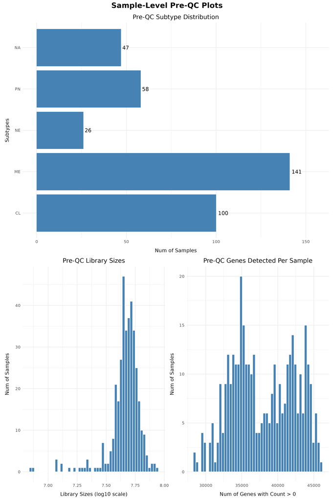

Sample-Level Pre-QC Plots

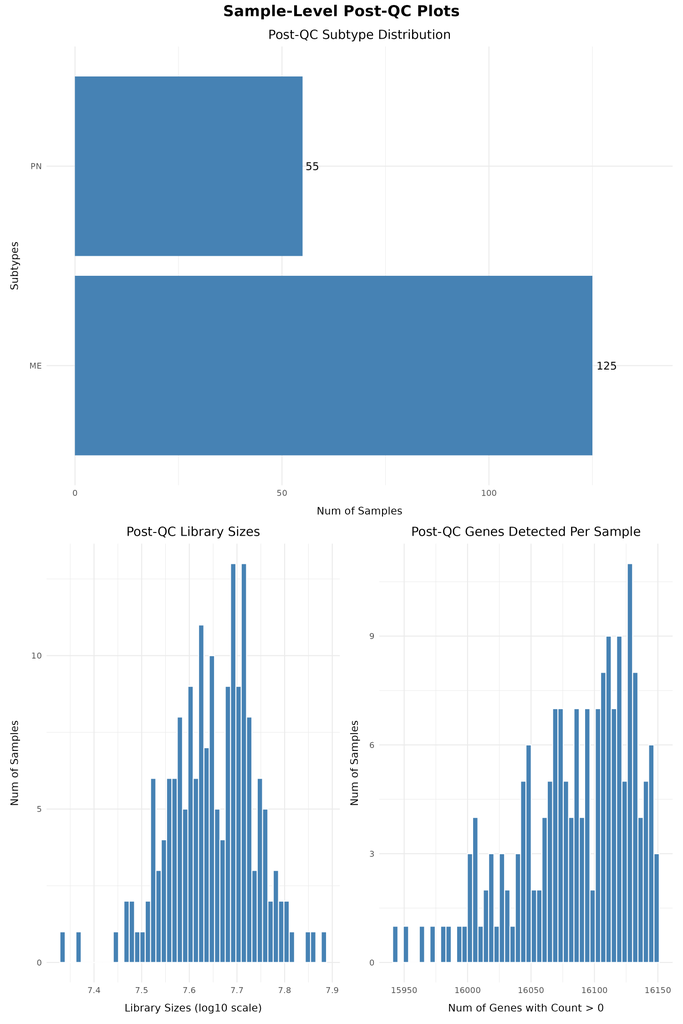

Sample-Level Post-QC Plots

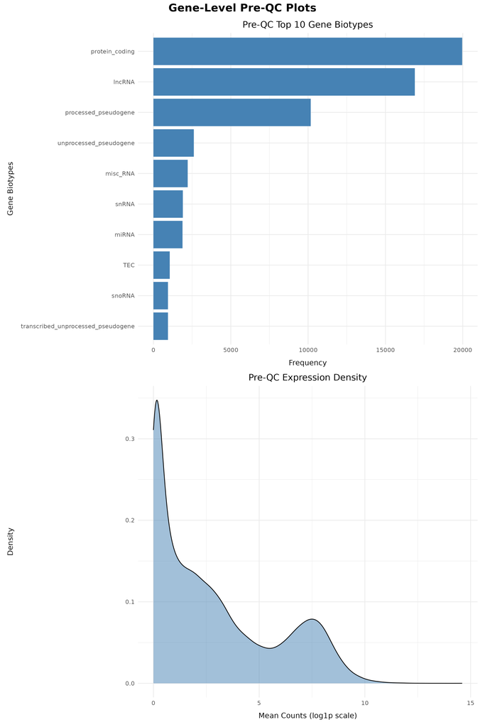

Gene-Level Pre-QC Plots

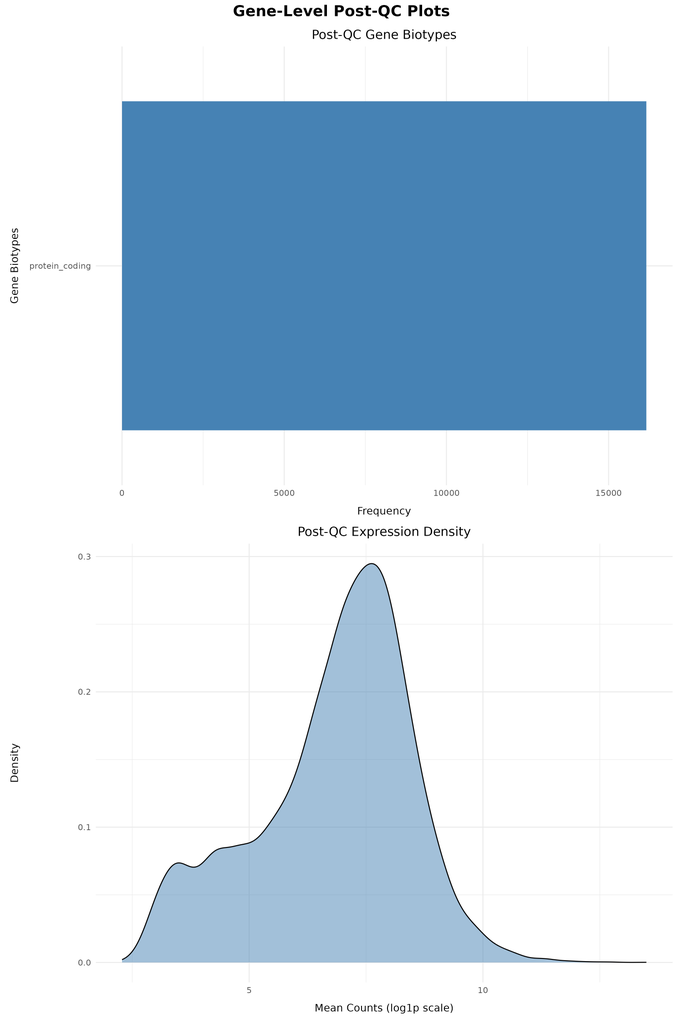

Gene-Level Post-QC Plots

### 2.4. Notebook 04: Perform EDA

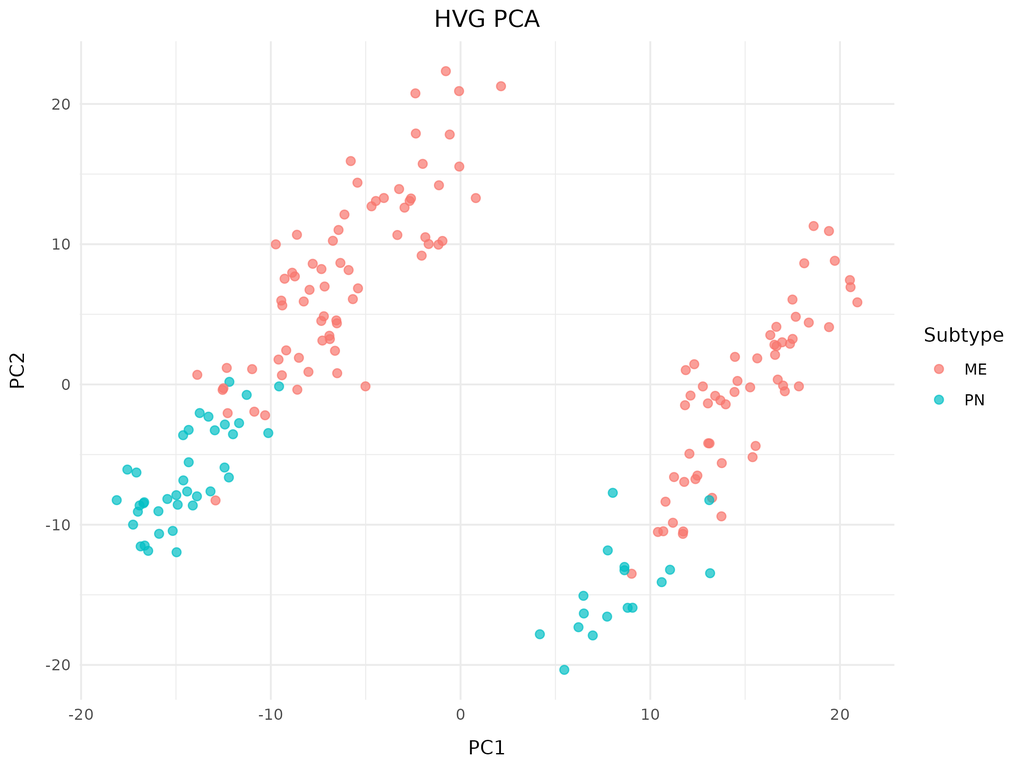

HVG PCA Plot

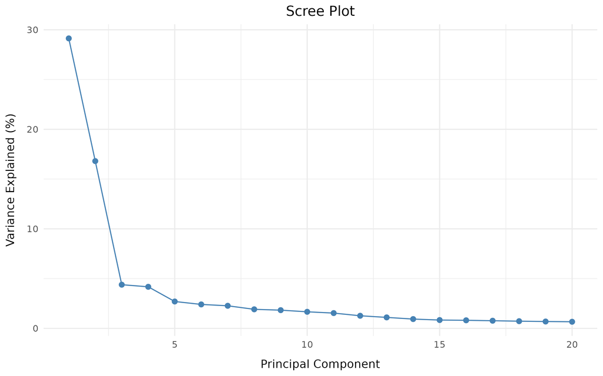

PCA Scree Plot

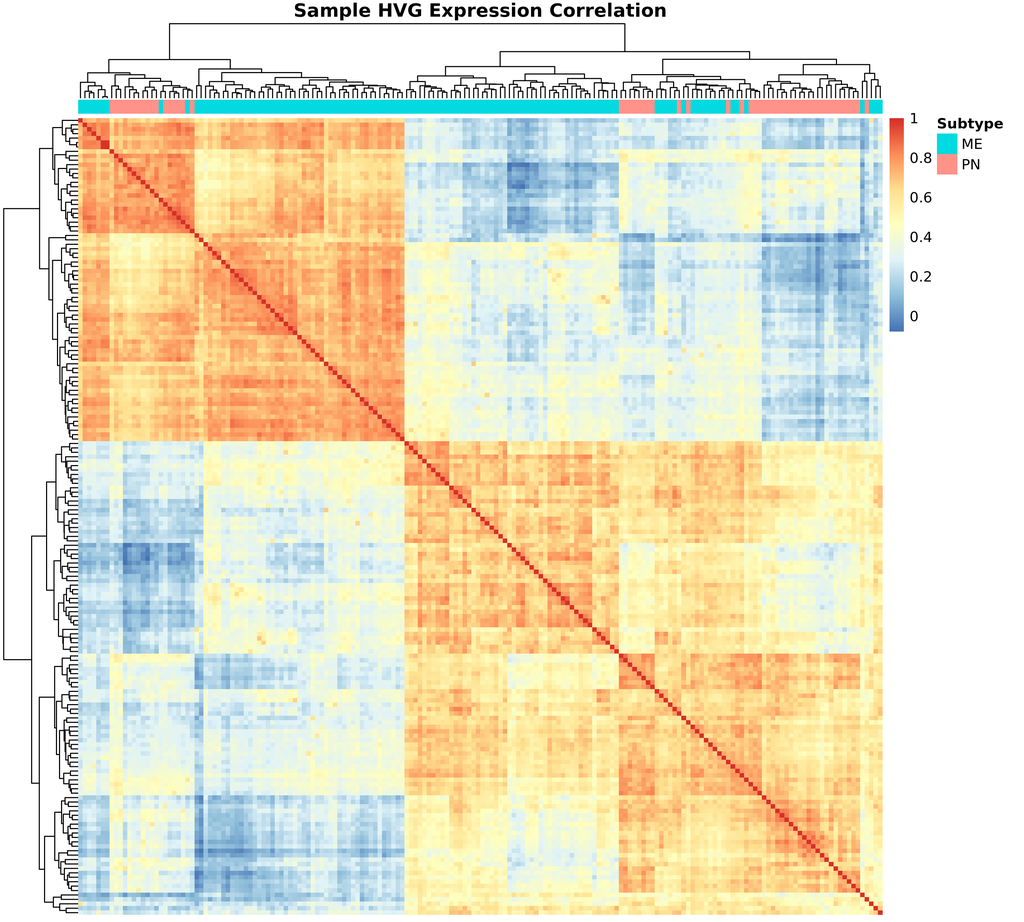

Sample Correlation Plot

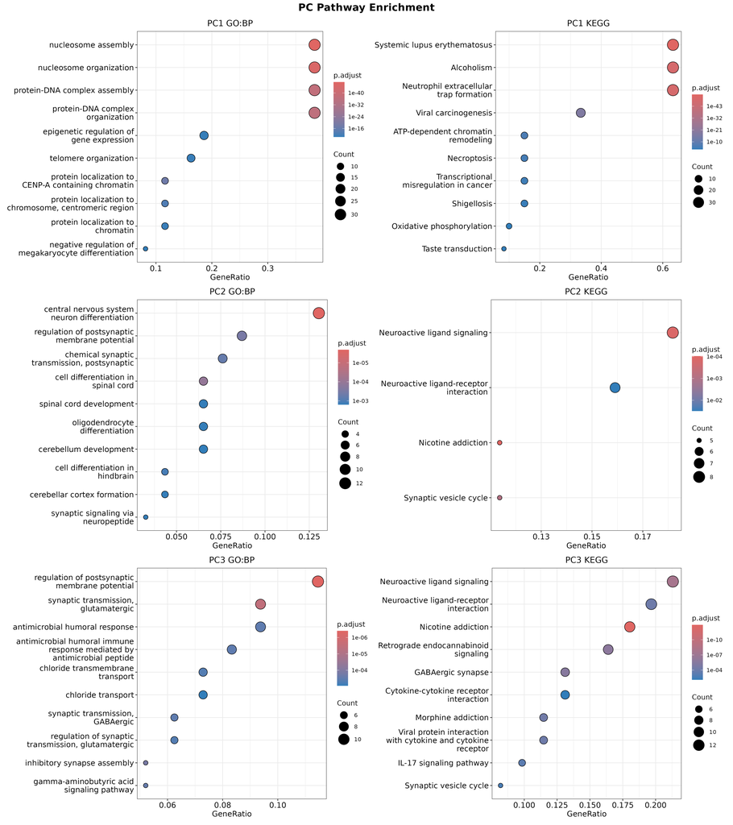

PC Enrichment Plots

### 2.5. Notebook 05: Perform DE Analysis

**Identified genes differentially expressed between ME and PN** subtypes (ME vs PN, PN as reference) using **two independent methods**:

- **DESeq2** **(primary)**:
  - **Wald test**
  - **`padj < 0.05`**
  - **`|log2FC| > 1`**
- **EdgeR** **(confirmatory)**:
  - **QL** **F-test**
  - **`FDR < 0.05`**
  - **`|logFC| > 1`**

**>94% consensus** between the two methods:

- **1,528 genes upregulated in ME**
- **1,130 genes downregulated in ME** (i.e. upregulated in PN) in the **intersections**.

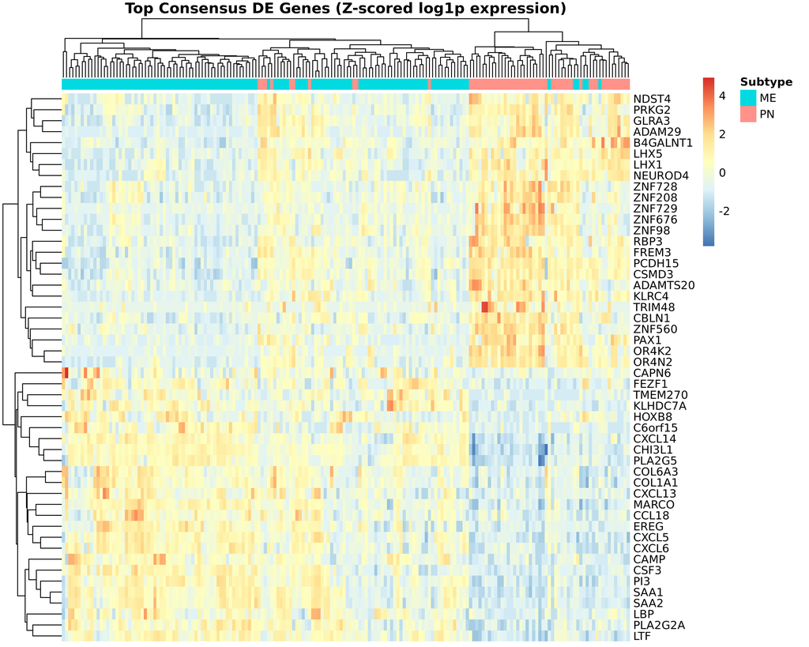

DE Genes Heatmap

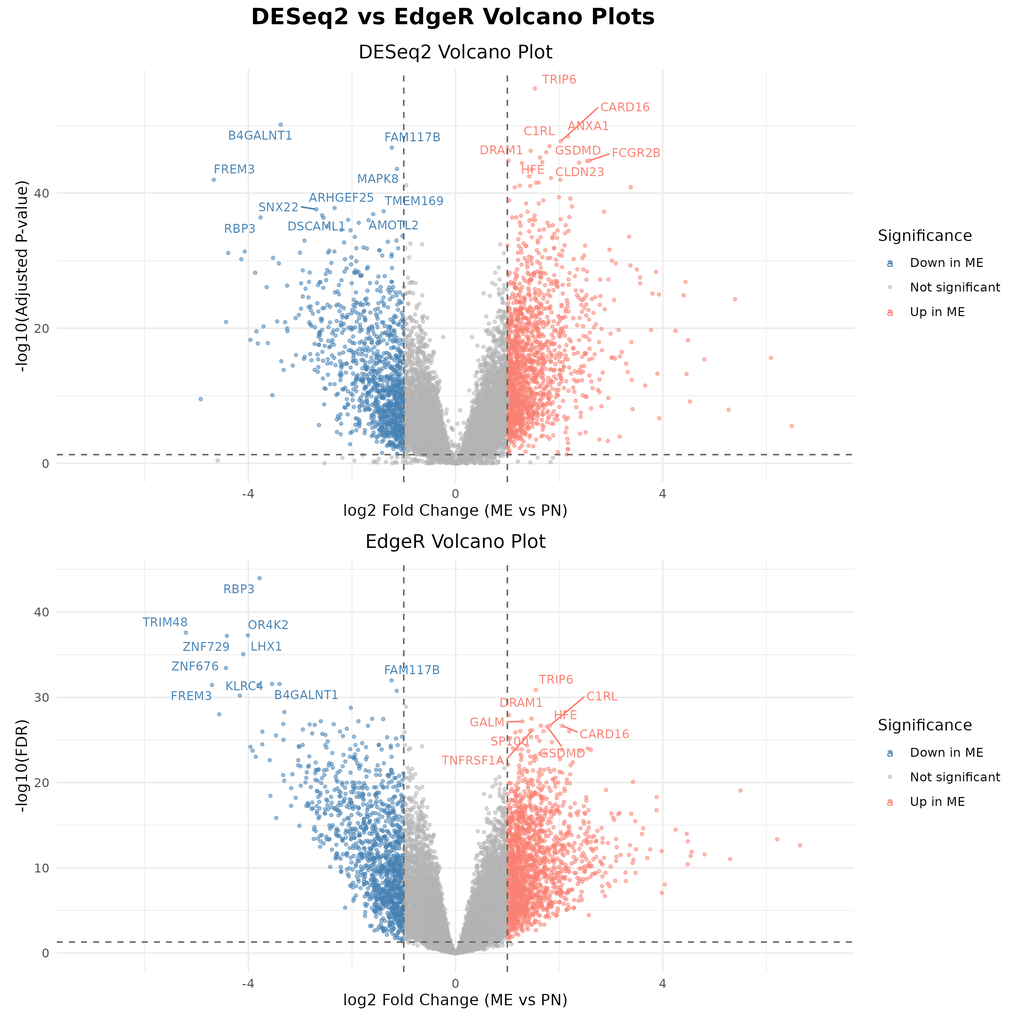

DESeq2 and EdgeR Volcano Plots

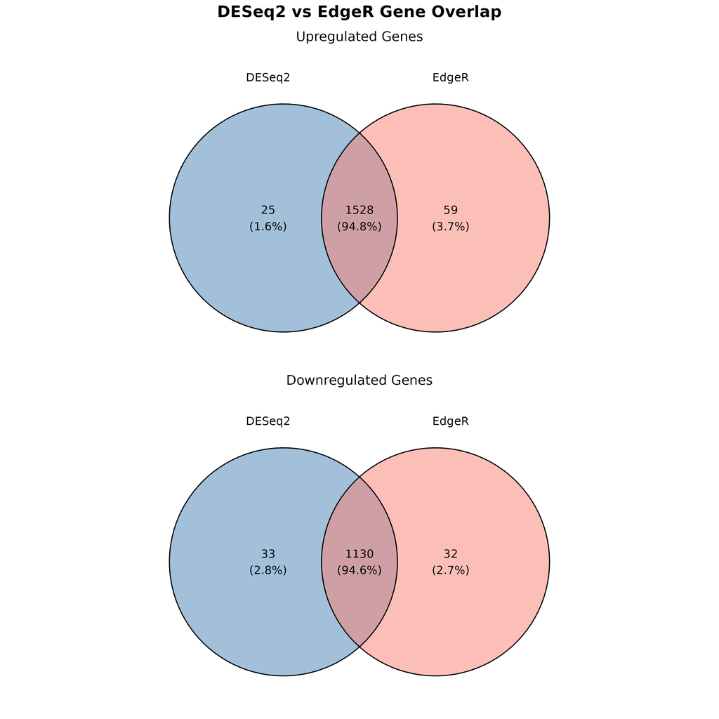

DESeq2 and EdgeR Consensus Overlaps

### 2.6. Notebook 06: Perform Pathway Enrichment

**Identified biological pathways enriched among the DE genes** using **two complementary methods** against **two pathway databases (GO:BP and KEGG)**:

- **ORA**: Tested the **consensus DE gene lists (upregulated and downregulated separately)** for **pathway overrepresentation**:
  - **Hypergeometric test**
  - **Benjamini-Hochberg (BH) correction**
  - **`padj < 0.05`**
  - **results were simplified using semantic similarity to remove redundant GO terms** (but **not KEGG**, as **its pathways represent independent, curated biochemical maps** rather than a hierarchical tree).
- **GSEA**: Tested the **full ranked gene list** **(all 16,164 genes**, **ranked by signed DESeq2 Wald statistic** and **independently by signed EdgeR F-statistic)** for **coordinated rank shifts**
  - **Benjamini-Hochberg (BH) correction**
  - **`padj < 0.05`**
  - **`eps = 0`**

**Both methods independently confirmed** the **same** two opposing **biological themes**:

- **Upregulated in ME**: A **mesenchymal/wound-healing program**.
  - **Immune cell recruitment** (leukocyte migration, cytokine signaling, adaptive immunity)
  - **ECM (ExtraCellular Matrix) remodeling**
  - Permanently active **inflammatory signaling**

  These pathways **collectively reflected the “wound that never heals” phenomenon** in cancer biology.
- **Downregulated in ME (upregulated in PN)**: A **neural identity + cell proliferation program**.
  - **ORA:**
    - **Axonogenesis**
    - **Synapse assembly**
    - **CNS neuron differentiation**
  - **GSEA:**
    - **Chromosome segregation**
    - **Nuclear division**
    - **DNA damage response**

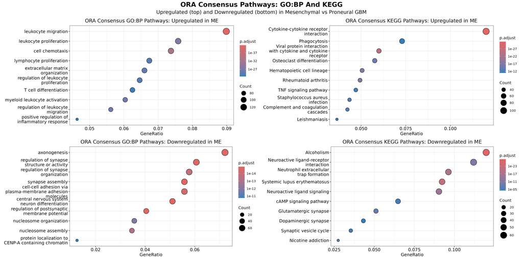

ORA Consensus Results

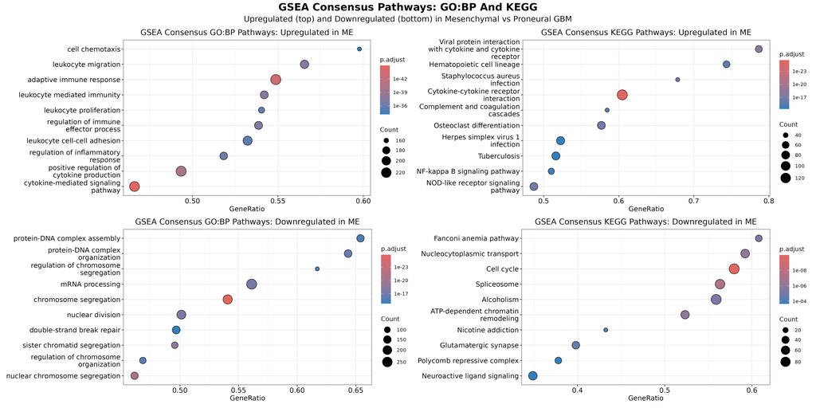

GSEA Consensus Results

### 2.7. Notebook 07: Perform Deconvolution

**Estimated the cellular composition of each tumor sample** from the bulk RNA-seq data using **MCPcounter** with **two custom GBM-specific marker gene sets**:

- **Primary:**
  - **Neftel neoplastic** states + **Moreno immune/stromal** types
  - AC, MES, NPC, OPC neoplastic states
  - TAM, Microglia, T cells, B cells, NK cells, DC, Monocytes, Mast cells, Mural cells, Endothelial cells, and others.
- **Confirmatory:**
  - **Moreno neoplastic** states + **Moreno immune/stromal** types
  - **Independent validation of the primary results** using a **different neoplastic marker** **set**.

**Both sets** confirmed the **same cell composition differences between subtypes**:

- **ME tumors**:
  - Enriched for **MES-like neoplastic cells** and **broad immune/stromal infiltrate** (TAMs, microglia, T/B/NK cells, endothelial, mural cells)
  - **Consistent** with the **mesenchymal/wound-healing program** identified in **Notebook 06**.
- **PN tumors**:
  - Enriched for **NPC/OPC-like neoplastic cells** and **neural cell types** (neurons, oligodendrocytes, radial glia
  - **Consistent** with the **neural identity program** identified in **Notebook 06**.

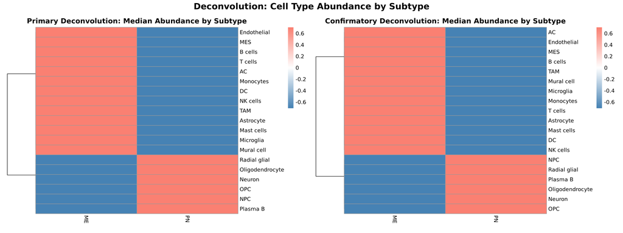

Deconvolution Results

### 2.8. Notebook 08: Integrate And Interpret Findings

The integration notebook **synthesized all upstream findings** into a **unified biological portrait of PN and ME GBM subtypes**, and **tested its clinical significance** via a **multivariate Cox proportional hazards model.**

**Pathway-cell type integration**:

- **Per-sample pathway activity scores (GSVA)** for **15 pathways across 3 biological themes** were **correlated against 19 cell type abundance scores**, computed **separately within ME and PN samples**.
- The **correlation patterns were strikingly consistent across both subtypes**, confirming these relationships **reflect general GBM biology** rather than subtype-specific artifacts.

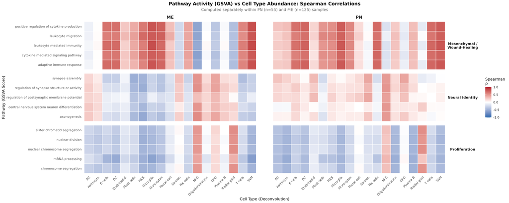

Pathway-Cell Type Correlation Heatmap

**Survival analysis**: A **Kaplan-Meier curve** confirmed a **statistically significant survival difference between subtypes (log-rank `p=0.033`)**, with **PN patients surviving longer on average**.

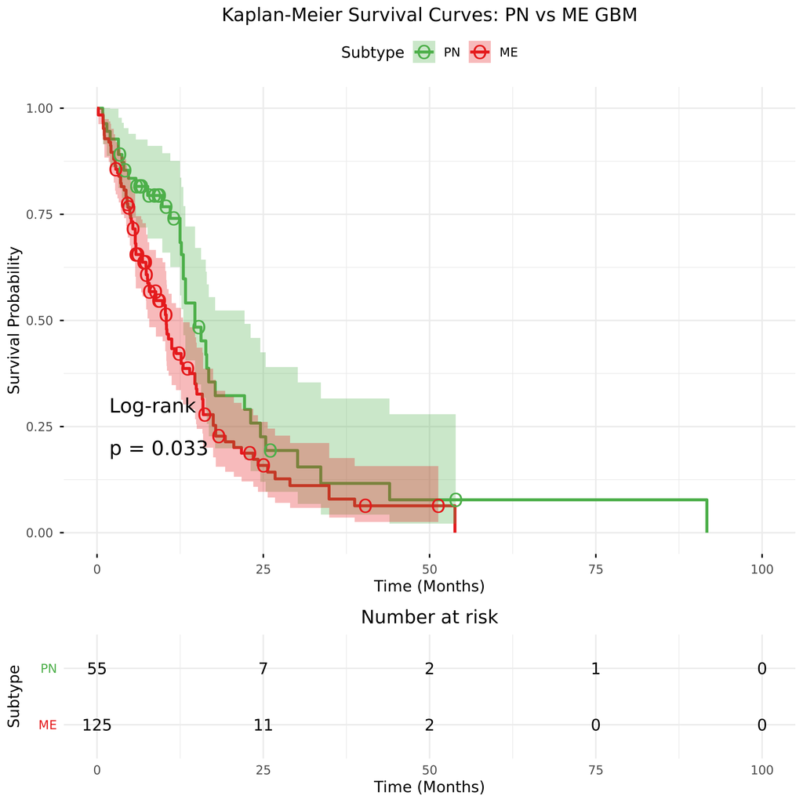

Kaplan-Meier Survival Curves

The multivariate **Cox proportional hazards model revealed** that:

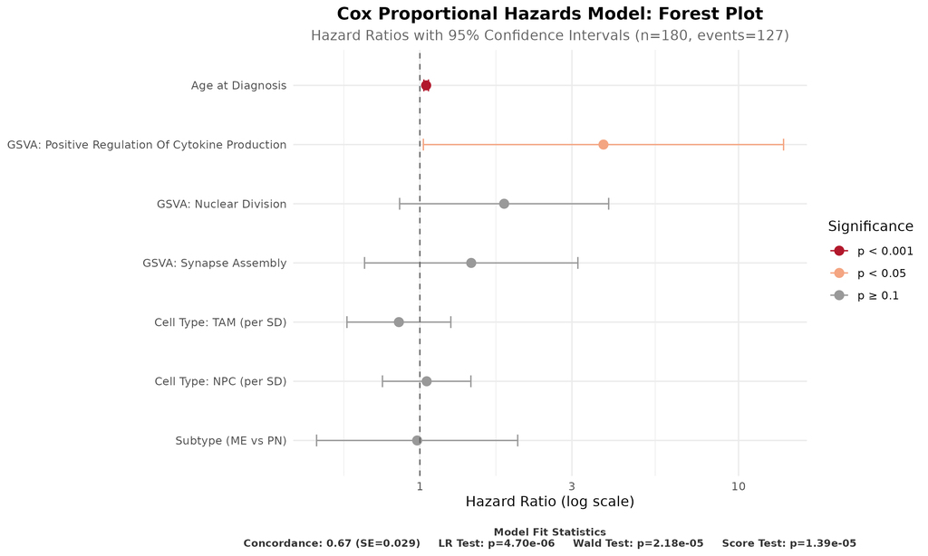

Cox Model Forest Plot

The **proportional hazards assumption was verified via Schoenfeld residuals** **(global `p=0.426`),** concluding that the **Cox model is statistically valid.**

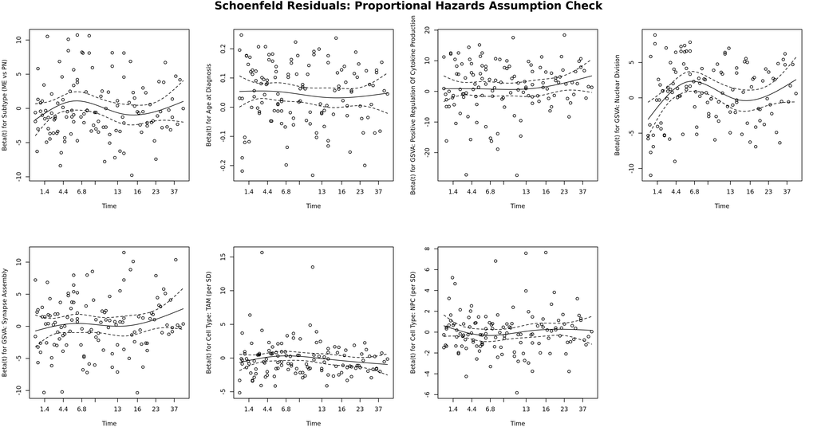

Schoenfeld Residuals

**Key insight**:

- The **survival difference between ME and PN** subtypes visible in the KM plot is **mediated through biological variables**, particularly **age distribution** and **immune/inflammatory pathway activity**, rather than being a direct effect of the subtype label itself.
- **It is NOT “being ME” that drives worse prognosis**, it is rather that the **biological characteristics that ME tumors tend to express do so.**